# Overview of Data Sources

Meridith L. Bartley

July 7, 2022

The goal of this consulting project is to develop a predictive model of trail use. The aim is to inform policy/methods adopted by land management agencies (Forest Service); also good for local decision makers.

# 1 Sources of Data

1. Headwaters Economics Counter Data
2. Strava Data (aggregated)
3. Weather covariate
4. Trail characteristics

## 1.1 Counter Data

From Headwaters Economics website:

> These data were collected using infrared counters rotated across 20 trails throughout the Bridgers. The counters record a use each time the beam is broken and were installed to minimize inaccurate counts from dogs or vegetation. Because this method measures total traffic, on a trail where use predominately is out-and-back the number of users will be approixmately half of the total traffic. Counters were installed for anywhere from 13 to 61 days, with an average of 29 days at each site. To ensure sufficient data were collected, counters were installed longest on trails that were more remote or had relatively low use.

See Figure 1.2 for locations of trail cameras.

(#tab:counter table)Total Number of Trail Camera Counts (2021)

| counterid | trailname | subsectionname | count | start | end |
| --- | --- | --- | --- | --- | --- |
| 1 | Fairy Lakeshore | NA | 3412 | 07-25 | 07-31 |
| 2 | Fairy Creek | NA | 376 | 08-05 | 09-07 |
| 3 | College M | NA | 4493 | 08-14 | 08-25 |
| 4 | Bridger Ridge | Baldy to Bridger | 1261 | 07-06 | 12-31 |
| 5 | Bridger Ridge | Baldy to Bridger | 1844 | 07-06 | 12-31 |
| 6 | Bridger Ridge | Bridger | 1689 | 07-06 | 12-31 |
| 7 | Bridger Ridge | Bridger to Ross Pass | 1582 | 07-06 | 12-31 |
| 8 | Bridger Ridge | M to Baldy | 2635 | 08-07 | 09-12 |
| 9 | Bridger Ridge | Ross Pass to Sacagawea Peak | 1508 | 07-06 | 12-31 |
| 10 | Bridger Ridge | Ross Pass to Sacagawea Peak | 310 | 07-12 | 12-31 |
| 11 | Bridger Ridge | Steep Way | 10122 | 08-27 | 09-26 |
| 12 | Sacagawea Pass | NA | 5192 | 08-05 | 09-09 |
| 13 | Sacagawea Pass | NA | 9485 | 07-12 | 12-31 |
| 14 | Horsethief Mountain | NA | 628 | 07-13 | 09-09 |
| 15 | Carroll Creek | NA | 757 | 08-07 | 09-09 |
| 16 | Felix Canyon | NA | 146 | 07-29 | 08-01 |
| 17 | Raptor View | NA | 158 | 07-13 | 08-09 |
| 18 | Sypes Canyon | NA | 3868 | 08-13 | 09-08 |
| 19 | Bridger Foothills | College M to Sypes | 834 | 08-14 | 08-25 |
| 20 | Truman Gulch | NA | 1585 | 08-12 | 08-28 |
| 21 | East Bridger South | NA | 321 | 07-13 | 08-09 |
| 22 | East Bridger North | NA | 780 | 07-13 | 08-09 |
| 23 | Shafthouse Hill | Lower Shafthouse | 687 | 07-03 | 09-09 |
| 24 | Shafthouse Hill | Upper Shafthouse | 303 | 07-03 | 07-05 |
| 25 | South Fork Flathead Creek | NA | 91 | 07-03 | 07-03 |
| 26 | Corbly Gulch | NA | 1766 | 06-27 | 07-26 |
| 27 | Corbly Gulch | NA | 165 | 07-13 | 12-31 |
| 28 | North Cottonwood | North Cottonwood to Johnson Canyon | 662 | 07-28 | 09-10 |
| 29 | North Cottonwood Access | NA | 2124 | 08-13 | 09-08 |
| 30 | Ross Pass | NA | 1246 | 07-13 | 08-09 |
| 31 | Middle Cottonwood | NA | 9060 | 06-27 | 08-16 |
| 32 | Johnson Canyon Jeep Trail | NA | 573 | 08-13 | 09-08 |
| 33 | Benchmark Rd | NA | 244 | 07-13 | 08-02 |

[figure not shown]

Figure 1.1: Timeseries plots of daily trail camera counts over time in the Bridger Mountains.

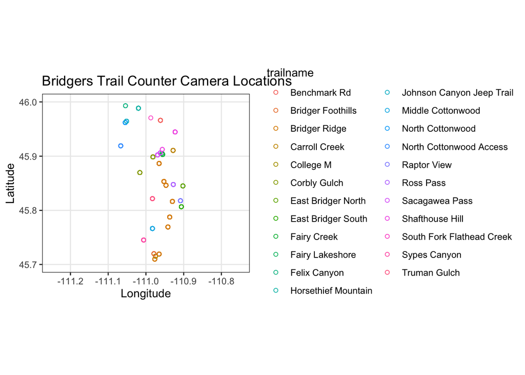

Figure 1.2: Trail Camera Locations in Bridgers

## 1.2 Strava Data

Strava count data are made available through Strava Metro. Data are binned (intervals of 5 with ceiling rounding) and aggregated on multiple scales (daily, monthly, annual). Counts are available as “total trips” and “total people”. Total trips should always be larger than the total people count as people sometimes make multiple passes of a single trail (e.g. M laps). Strava trails are subdivided into “edges”. Edge IDs (for the trailhead edge?) are available in the Counter data. Strava count data are available for the entire year of 2021 (not just summer monitoring as in the counter data). These data also include the overarching trail name and number (e.g. 511 - Bridger Foothills) that also correspond to the counter data provided by HE.

It is important to note that when considering Strava data at the Trail scale (rather than edge scale) you are propagating rounding errors for each segment forward (+_ 1-4 for each edge?). Similarly, aggregating the data in the daily dataframe to a monthly timescale will likely not match the information provided in the monthly dataframe.

### 1.2.1 Join IDs

(#tab:strava table)Total Number of Strava Counts (2021)

| trailname | count | start | end |
| --- | --- | --- | --- |
| Bridger Foothills | 46750 | 01-01 | 12-02 |
| Bridger Ridge | 46280 | 01-01 | 09-30 |
| Carrol Creek | 360 | 06-19 | 09-05 |
| College M | 22030 | 01-01 | 09-30 |
| Corbly Gulch | 9870 | 03-28 | 12-04 |
| E Bridger North | 2495 | 01-09 | 10-10 |
| E Bridger South | 25 | 06-23 | 08-07 |
| Fairy Creek | 785 | 06-02 | 10-02 |
| Fairy Lake Shortcut | 140 | 06-11 | 09-25 |
| Fairy Lakeshore | 310 | 06-02 | 09-26 |
| Felix Canyon Rd | 600 | 04-17 | 12-03 |
| Flathead Pass Rd | 105 | 06-19 | 10-16 |
| Johnson Canyon Jeep Trail | 20 | 06-12 | 06-12 |
| M shortcut | 4015 | 01-01 | 09-30 |
| Middle Cottonwood | 12295 | 01-02 | 10-31 |
| New World Gulch | 1070 | 01-30 | 10-03 |
| North Cottonwood | 2180 | 02-20 | 11-06 |
| North Cottonwood Access | 1155 | 01-18 | 09-30 |
| Raptor View | 270 | 06-26 | 09-29 |
| Ross Pass | 765 | 06-06 | 10-02 |
| S Fork Brackett Creek | 55 | 06-22 | 10-02 |
| Sacagawea Pass | 2055 | 06-12 | 09-26 |
| Shafthouse Hill | 1035 | 06-12 | 10-10 |
| Sypes Canyon | 19005 | 01-01 | 11-21 |
| Truman Gulch | 5375 | 01-10 | 12-04 |
| Upper Brackett Creek | 105 | 06-27 | 10-02 |

## 1.3 Weather Covariates

The following weather covariates are available on a daily basis:

1. Precipitation (in.)
2. Temperature Max (degrees Fahrenheit)
3. Temperature Min (degrees Fahrenheit)
4. Mean Air Quality (AQI)
5. Mean PM_25 Concentration (micrograms per cubic meter)

These data do not vary spatially only temporally (i.e. the resolution is not fine enough to parse out different weather between trails on a given day).

Missing data (days):

- Precipitation: 0
- Max Temp: 13
- Min Temp: 6
- AQI: 6
- Particulate Matter: 6

[figure not shown]

# 2 Questions

1. At what resolution is prediction desired? (e.g. at trail segment level or at entire trail level. The latter is more likely with available data.)
2. To confirm: some trail/subsections have multiple cameras deployed?
3. Have the count numbers for the deployed cameras already been halved for out-and-back trails? Are there any loop trails?
4. To confirm: no outlier counter data in this dataset have been altered?
5. Is there data for trail length (or trail segment/edge length for Strava)?
6. Is there hourly information for the trail counter data? Also information for total elevation change?
7. Do the edge IDs in trail_count correspond to the trailhead edge segments?
8. Shapefile with (coarse scale - full trail no edges) full trail location?
9. If a trail use camera was deployed through the end of 2021

Future: how many people double track hikes with Strava and AllTrails. (likely more often for long, technical trails that require navigation)